# ippolito_assignment08

#### Michael Ippolito DATA602 - Assignment 8 4/21/2022

## Introduction

This data set comes from the UCI Machine Learning Repository and includes evaluations of 115 Swiss engineering students. Data was collected while the students took six exams each. Data was collected about each student's keystrokes, mouse movements, and test times, along with how the student performed on the exam. I chose the data set because it included a good mix of variables, both numerical and categorical, with which to demonstrate various plot types.

```python
# Load libraries
import pandas as pd
import numpy as np
from matplotlib import pyplot as plt
import seaborn as sns
import os
import re
```

## Load data

```python
# Set column names
colnamesArray = ['session', 'student_id', 'exercise', 'activity', 'start_time', 'end_time',
                'idle_time', 'mouse_wheel', 'mouse_wheel_click', 'mouse_click_left',
                 'mouse_click_right', 'mouse_movement', 'keystroke']

# Load session data
dir = 'C:/Users/micha/Downloads/EPM_Dataset_2/Data/Processes'
ct = 0
for subdir in os.listdir(dir):

    # Read files in each subdir
    subdir_fullpath = os.path.join(dir, subdir)
    print("Reading", subdir_fullpath)
    for fn in os.listdir(subdir_fullpath):

        # Build path and read data frame
        ct += 1
        fullpath = os.path.join(subdir_fullpath, fn)
        df = pd.read_csv(fullpath, converters={4: str, 5: str})
        df.columns = colnamesArray

        # Append data to df2
        if ct == 1:
            df2 = df.copy()
        else:
            df2 = pd.concat([df2, df])

        # Remove the dataframe from memory
        del df

# Load grade data
print("Reading C:/Users/micha/Downloads/EPM_Dataset_2/Data/final_grades.csv")
dfgr = pd.read_csv("C:/Users/micha/Downloads/EPM_Dataset_2/Data/final_grades.csv")
print()
print("Done reading data")
```

```
Reading C:/Users/micha/Downloads/EPM_Dataset_2/Data/Processes\Session 1
Reading C:/Users/micha/Downloads/EPM_Dataset_2/Data/Processes\Session 2
Reading C:/Users/micha/Downloads/EPM_Dataset_2/Data/Processes\Session 3
Reading C:/Users/micha/Downloads/EPM_Dataset_2/Data/Processes\Session 4
Reading C:/Users/micha/Downloads/EPM_Dataset_2/Data/Processes\Session 5
Reading C:/Users/micha/Downloads/EPM_Dataset_2/Data/Processes\Session 6
Reading C:/Users/micha/Downloads/EPM_Dataset_2/Data/final_grades.csv

Done reading data
```

## Exploratory data analysis

```python
# General info
print("Session data shape:", df2.shape)
print("Grades shape:", dfgr.shape)
print()
print("Session data info:")
print(df2.info())
print()
print("Grades info:")
print(dfgr.info())
print()

# Summary stats
print("Session data summary stats:")
print(df2.describe())
print()
print("Grades summary stats:")
print(dfgr.describe())
print()
```

```
Session data shape: (229798, 13)
Grades shape: (114, 19)

Session data info:
<class 'pandas.core.frame.DataFrame'>
Int64Index: 229798 entries, 0 to 527
Data columns (total 13 columns):
 #   Column             Non-Null Count   Dtype
---  ------             --------------   -----
 0   session            229798 non-null  int64
 1   student_id         229798 non-null  int64
 2   exercise           229798 non-null  object
 3   activity           229798 non-null  object
 4   start_time         229798 non-null  object
 5   end_time           229798 non-null  object
 6   idle_time          229798 non-null  int64
 7   mouse_wheel        229798 non-null  int64
 8   mouse_wheel_click  229798 non-null  int64
 9   mouse_click_left   229798 non-null  int64
 10  mouse_click_right  229798 non-null  int64
 11  mouse_movement     229798 non-null  int64
 12  keystroke          229798 non-null  int64
dtypes: int64(9), object(4)
memory usage: 24.5+ MB
None

Grades info:
<class 'pandas.core.frame.DataFrame'>
RangeIndex: 114 entries, 0 to 113
Data columns (total 19 columns):
 #   Column      Non-Null Count  Dtype
---  ------      --------------  -----
 0   student_id  114 non-null    int64
 1   attempt     114 non-null    int64
 2   es_1.1      114 non-null    float64
 3   es_1.2      114 non-null    float64
 4   es_2.1      114 non-null    float64
 5   es_2.2      114 non-null    float64
 6   es_3.1      114 non-null    float64
 7   es_3.2      114 non-null    int64
```

[output cut: 71 more lines]

```
min      0.000000    0.000000    0.000000    0.000000    0.000000    0.000000
25%      2.000000    0.000000    0.000000    0.000000    0.000000    0.000000
50%      4.500000    1.000000    4.000000    1.500000    8.000000    6.500000
75%      9.750000    2.000000    8.000000    3.000000   19.000000   12.750000
max     10.000000    2.000000   10.000000    3.000000   25.000000   15.000000

            total
count  114.000000
mean    54.460526
std     27.420694
min      7.000000
25%     30.500000
50%     54.000000
75%     78.750000
max     98.000000
```

```python
# Peek at data - process data
df2.head()
```

|  | session | student_id | exercise | activity | start_time | end_time | idle_time | mouse_wheel | mouse_wheel_click | mouse_click_left | mouse_click_right | mouse_movement | keystroke |
| --- | --- | --- | --- | --- | --- | --- | --- | --- | --- | --- | --- | --- | --- |
| 0 | 1 | 1 | Es | Aulaweb | 2.10.2014 11:25:35 | 2.10.2014 11:25:42 | 218 | 0 | 0 | 4 | 0 | 397 | 0 |
| 1 | 1 | 1 | Es | Blank | 2.10.2014 11:25:43 | 2.10.2014 11:25:43 | 0 | 0 | 0 | 0 | 0 | 59 | 0 |
| 2 | 1 | 1 | Es | Deeds | 2.10.2014 11:25:44 | 2.10.2014 11:26:17 | 154117 | 6 | 0 | 8 | 0 | 1581 | 4 |
| 3 | 1 | 1 | Es | Other | 2.10.2014 11:26:18 | 2.10.2014 11:26:18 | 0 | 0 | 0 | 2 | 0 | 103 | 0 |
| 4 | 1 | 1 | Es | Other | 2.10.2014 11:26:19 | 2.10.2014 11:26:27 | 460 | 0 | 0 | 4 | 0 | 424 | 8 |

```python
# Peek at data - grade data
dfgr.head()
```

|  | student_id | attempt | es_1.1 | es_1.2 | es_2.1 | es_2.2 | es_3.1 | es_3.2 | es_3.3 | es_3.4 | es_3.5 | es_4.1 | es_4.2 | es_5.1 | es_5.2 | es_5.3 | es_6.1 | es_6.2 | total |
| --- | --- | --- | --- | --- | --- | --- | --- | --- | --- | --- | --- | --- | --- | --- | --- | --- | --- | --- | --- |
| 0 | 3 | 1 | 2.0 | 3.0 | 1.0 | 2.0 | 1.0 | 2 | 2.0 | 2.0 | 3.0 | 15.0 | 10.0 | 1.0 | 5.0 | 3.0 | 18.0 | 15.0 | 85.0 |
| 1 | 6 | 1 | 2.0 | 3.0 | 2.0 | 3.0 | 1.0 | 2 | 2.0 | 0.0 | 3.0 | 15.0 | 7.0 | 2.0 | 9.0 | 3.0 | 13.0 | 15.0 | 82.0 |
| 2 | 7 | 1 | 2.0 | 3.0 | 1.0 | 1.5 | 1.0 | 2 | 0.0 | 0.0 | 3.0 | 5.0 | 4.0 | 0.0 | 0.0 | 3.0 | 17.0 | 10.0 | 52.5 |
| 3 | 10 | 1 | 2.0 | 3.0 | 2.0 | 1.5 | 1.0 | 2 | 0.0 | 2.0 | 3.0 | 11.0 | 1.0 | 2.0 | 10.0 | 1.5 | 7.0 | 10.0 | 59.0 |
| 4 | 13 | 1 | 2.0 | 3.0 | 2.0 | 1.5 | 1.0 | 2 | 2.0 | 2.0 | 3.0 | 14.5 | 10.0 | 2.0 | 2.0 | 3.0 | 25.0 | 15.0 | 90.0 |

```python
# Look for missing data
print(df2.isna().sum())
print(dfgr.isna().sum())
```

```
session              0
student_id           0
exercise             0
activity             0
start_time           0
end_time             0
idle_time            0
mouse_wheel          0
mouse_wheel_click    0
mouse_click_left     0
mouse_click_right    0
mouse_movement       0
keystroke            0
dtype: int64
student_id    0
attempt       0
es_1.1        0
es_1.2        0
es_2.1        0
es_2.2        0
es_3.1        0
es_3.2        0
es_3.3        0
es_3.4        0
es_3.5        0
es_4.1        0
es_4.2        0
es_5.1        0
es_5.2        0
es_5.3        0
es_6.1        0
es_6.2        0
total         0
dtype: int64
```

## Data wrangling

```python
# Start times are in this format: 2.10.2014 11:35:32; convert to ISO8601
df2['start_time'] = df2['start_time'].str.replace('\.', '-', regex=True)
df2['end_time'] = df2['end_time'].str.replace('\.', '-', regex=True)
df2['start_time'] = pd.to_datetime(df2['start_time'])
df2['end_time'] = pd.to_datetime(df2['end_time'])
```

```python
# Remove idle time outlier (-425860446967950)
df2.drop(df2[df2.idle_time < 0].index, inplace=True)
```

```python
# Group process data by student_id
df3 = \
    df2.groupby(['student_id']).agg({'idle_time': 'sum'}).merge(
        df2.groupby(['student_id']).agg({'mouse_wheel': 'sum'}), how='outer', on='student_id'
    ).merge(
        df2.groupby(['student_id']).agg({'mouse_wheel_click': 'sum'}), how='outer', on='student_id'
    ).merge(
        df2.groupby(['student_id']).agg({'mouse_click_left': 'sum'}), how='outer', on='student_id'
    ).merge(
        df2.groupby(['student_id']).agg({'mouse_click_right': 'sum'}), how='outer', on='student_id'
    ).merge(
        df2.groupby(['student_id']).agg({'mouse_movement': 'sum'}), how='outer', on='student_id'
    ).merge(
        df2.groupby(['student_id']).agg({'keystroke': 'sum'}), how='outer', on='student_id'
    )
```

```python
# Get mean of each student's test grade (attempt 1 and attempt 2)
df4 = dfgr.groupby(['student_id']).agg({'total': 'mean'})

# Merge grade with process data
df5 = df4.merge(df3, how='outer', on='student_id')

# Peek at data
df5.head()
```

| student_id | total | idle_time | mouse_wheel | mouse_wheel_click | mouse_click_left | mouse_click_right | mouse_movement | keystroke |
| --- | --- | --- | --- | --- | --- | --- | --- | --- |
| 1 | 94.5 | 809020642 | 4360 | 0 | 15531 | 674 | 1135011 | 8835 |
| 2 | 44.0 | 1200277190 | 2388 | 0 | 7960 | 372 | 372611 | 9549 |
| 3 | 85.0 | 648688919 | 1965 | 0 | 9119 | 487 | 497019 | 9307 |
| 4 | 30.0 | 2208869669 | 6898 | 14 | 16733 | 530 | 595517 | 17759 |
| 5 | 38.5 | 1347480851 | 4528 | 0 | 13542 | 518 | 1167203 | 13867 |

## Visualizations - Part 1 (Matplotlib)

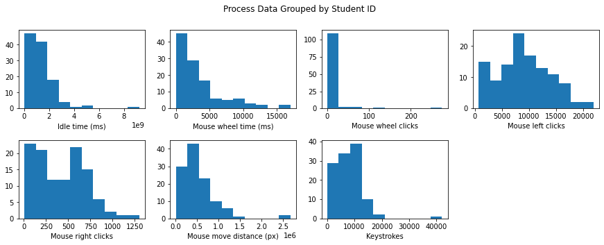

```python
# 1. Change the title and x/y labels

# Histograms of process data grouped by student_id
plt.clf()
(pf, pa) = plt.subplots(2, 4, figsize=(15,5))
plt.suptitle('Process Data Grouped by Student ID')
plt.subplots_adjust(hspace=0.4)
plt.subplot(2, 4, 1)
plt.xlabel('Idle time (ms)')
plt.hist(data=df5, x='idle_time')
plt.subplot(2, 4, 2)
plt.xlabel('Mouse wheel time (ms)')
plt.hist(data=df5, x='mouse_wheel')
plt.subplot(2, 4, 3)
plt.xlabel('Mouse wheel clicks')
plt.hist(data=df5, x='mouse_wheel_click')
plt.subplot(2, 4, 4)
plt.xlabel('Mouse left clicks')
plt.hist(data=df5, x='mouse_click_left')
plt.subplot(2, 4, 5)
plt.xlabel('Mouse right clicks')
plt.hist(data=df5, x='mouse_click_right')
plt.subplot(2, 4, 6)
plt.xlabel('Mouse move distance (px)')
plt.hist(data=df5, x='mouse_movement')
plt.subplot(2, 4, 7)
plt.xlabel('Keystrokes')
plt.hist(data=df5, x='keystroke')
plt.subplot(2, 4, 8)
pa[-1, -1].axis('off')
plt.show()
```

[figure not shown]

```python
# 2. Change the marker, point colors, and point size
# 3. Place a legend outside of the plot
# 4. Change a legend font size
# 5. Modify Axis Text Ticks/Labels
# 6. Change size of axis Labels
# 7. Add annotations

# Scatter plot of grades by mouse wheel time
plt.clf()
plt.scatter(data=df5, x='mouse_click_left', y='total', color='#00aa00', marker='*', s=50, alpha=.5)  # change markers
plt.scatter(data=df5, x='keystroke', y='total', color='#aa00aa', marker='+', s=20, alpha=.5)         # change markers
plt.title('Left clicks and keystrokes')
plt.ylabel('Mean total grade')
plt.legend(['Left clicks', 'Keystrokes'], loc=(1.04,0), prop={'size': 11})  # place legend outside the plot
plt.xticks(ticks=np.arange(0, 50001, step=10000))                           # change step of x-ticks
plt.yticks(ticks=np.arange(0, 101, step=10))                                # change step of y-ticks
plt.gca().yaxis.label.set_size(11)                                          # set size of y-axis label
plt.annotate(text='outlier', xy=(48000, 85), xytext=(45000, 90))            # annotate the outlier
plt.show()
```

## Visualizations - Part 2 (Seaborn)

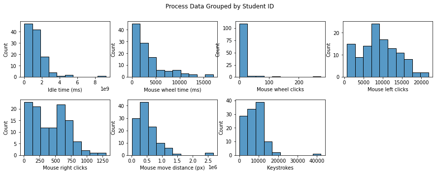

```python
# Recreate histograms using seaborn
plt.clf()
(pf, pa) = plt.subplots(2, 4, figsize=(15,5))
plt.suptitle('Process Data Grouped by Student ID')
plt.subplots_adjust(hspace=0.4)
sns.histplot(data=df5, x="idle_time", ax=pa[0,0], bins=10)
pa[0,0].set_xlabel('Idle time (ms)')
sns.histplot(data=df5, x="mouse_wheel", ax=pa[0,1], bins=10)
pa[0,1].set_xlabel('Mouse wheel time (ms)')
sns.histplot(data=df5, x="mouse_wheel_click", ax=pa[0,2], bins=10)
pa[0,2].set_xlabel('Mouse wheel clicks')
sns.histplot(data=df5, x="mouse_click_left", ax=pa[0,3], bins=10)
pa[0,3].set_xlabel('Mouse left clicks')
sns.histplot(data=df5, x="mouse_click_right", ax=pa[1,0], bins=10)
pa[1,0].set_xlabel('Mouse right clicks')
sns.histplot(data=df5, x="mouse_movement", ax=pa[1,1], bins=10)
pa[1,1].set_xlabel('Mouse move distance (px)')
sns.histplot(data=df5, x="keystroke", ax=pa[1,2], bins=10)
pa[1,2].set_xlabel('Keystrokes')
pa[-1, -1].axis('off')
plt.show()
```

[figure not shown]

```python
# Recreate scatter plot using seaborn;
# seaborn seems to make markers smaller than matplotlib, so double the size here
plt.clf()
sns.scatterplot(data=df5, x='mouse_click_left', y='total', color='#00aa00', marker='*', s=100, alpha=.5)  # change markers
sns.scatterplot(data=df5, x='keystroke', y='total', color='#aa00aa', marker='+', s=40, alpha=.5)          # change markers
plt.title('Left clicks and keystrokes')
plt.ylabel('Mean total grade')
plt.legend(['Left clicks', 'Keystrokes'], loc=(1.04,0), prop={'size': 11})  # place legend outside the plot
plt.xticks(ticks=np.arange(0, 50001, step=10000))                           # change step of x-ticks
plt.yticks(ticks=np.arange(0, 101, step=10))                                # change step of y-ticks
plt.gca().yaxis.label.set_size(11)                                          # set size of y-axis label
plt.annotate(text='outlier', xy=(48000, 85), xytext=(45000, 90))            # annotate the outlier
plt.show()
```

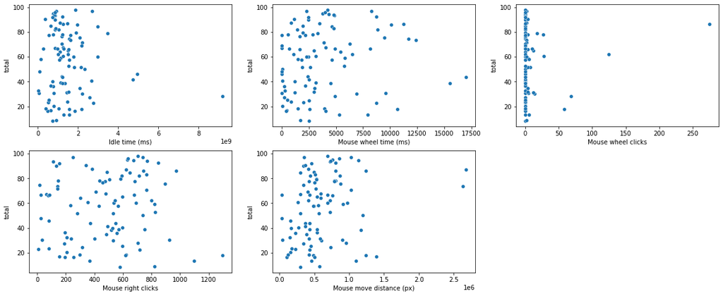

```python
# Show a few more scatter plots to visually look for a correlation between total and the other variables
(pf, pa) = plt.subplots(2, 3, figsize=(20,8))
sns.scatterplot(data=df5, x='idle_time', y='total', ax=pa[0,0])
pa[0,0].set_xlabel('Idle time (ms)')
sns.scatterplot(data=df5, x='mouse_wheel', y='total', ax=pa[0,1])
pa[0,1].set_xlabel('Mouse wheel time (ms)')
sns.scatterplot(data=df5, x='mouse_wheel_click', y='total', ax=pa[0,2])
pa[0,2].set_xlabel('Mouse wheel clicks')
sns.scatterplot(data=df5, x='mouse_click_right', y='total', ax=pa[1,0])
pa[1,0].set_xlabel('Mouse right clicks')
sns.scatterplot(data=df5, x='mouse_movement', y='total', ax=pa[1,1])
pa[1,1].set_xlabel('Mouse move distance (px)')
pa[-1, -1].axis('off')
plt.show()
```

## Visualizations - Part 3 (Differences)

For starters, it took fewer statements to create the same plots in Seaborn, especially when it came to subplots. In Matplotlib, each subplot had to be initialized with a plt.subplot statement, while in Seaborn the axis could just be passed to the plot statement as an argument.

Seaborn also spaced the plots out better, while Matplotlib jammed the plots up against each other, even overrunning the x-axis labels with the plot below it. That required me to manually set the plot spacing, while Seaborn seemed to do it more intelligently on its own.

The thing that Seaborn didn't do very well automatically was decide binwidth. In one of the plots, the binwidth was so small that at first it looked like an empty plot. Adjusting it manually fixed the problem. In a different plot, there was an outlier with a very large negative number; Matplotlib handled this with no problem, while Seaborn churned on it for a full five minutes before I had to kill the kernel and figure out what it was doing. Removing the outlier fixed the issue, but it was interesting that Matplotlib handled it while Seaborn was kind of like Tom Cruise in A Few Good Men: It couldn't handle the truth.